# Snowshoe Report: Exploratory Report on Juvenile Snowshoe Hares at Bonanza Creek Experimental Forest

Lauren Harris

11/4/2021

# 1 Introduction

This study explores data of juvenile snowshoe hares (*Lepus americanus*) collected from the Bonanza Creek Experimental Forest LTER site in Fairbanks, Alaska from 1999 to 2012 in a capture-recapture study of both adults and juveniles (Kielland et al., 2017). First, juvenile hare trap counts are compared annually. Second, juvenile hare body weight across sex and site (sites include Bonanza Mature, Bonanza Riparian, Bonanza Spruce) are explored. Third, juvenile weight comparisons are made across the sexes (ignoring site). Fourth, the relationship between juvenile body weight and hind foot length is analyzed.

**Site descriptions:**

- **Bonanza Mature:** This location includes stands of mature white spruce, paper birch, and alder, as well as black spruce, Labrador tea, willows, and prickly rose
- **Bonanza Riparian:** This location is a flood zone along the Tanana River and Bonanza Mature is a mature black spruce forest approximately 1 km inland from the river and 2 km from the riparian plot. Bonanza Riparian consisted of willow, paper birch, alder, white spruce, fireweed and several grasses
- **Bonanza Spruce:** This location was a mature lowland black spruce stand used for live-trapping snowshoe hares to monitor abundance and survival

# 2 Data and Analyses

Data was collected from the Bonanza Creek Experimental Forest LTER site from 1999 to 2012 (Kielland et al., 2017). The number of observations including observations of adults is 3197. **Section 1** visualizes annual juvenile hare trap counts in a histogram. **Section 2** visualizes the body weight of juvenile hares of different sexes (male, female, unknown) across 3 sites (Bonanza Mature, Bonanza Riparian, Bonanza Spruce) through boxplots and a table including mean, median, standard deivation and sample size. **Section 3** explores the summary statistics (mean, standard deviation, sample size) of weight by sex in a table. Effect size was determined using Cohen’s d and a two sample unpaired t-test was run with a significance level of 0.05. **Section 4** includes a simple linear model using hind foot length to predict body weight and a test of correlation to find Pearson’s r, as well as a scatter plot of hind foot length and body weight. All analyses are in R version 4.0.2 using RStudio version 2021.09.0.

# 3 Juvenile Hare Initial Investigation

## 3.1 Annual Juvenile Hare Trap Counts

This section includes a histogram which compares the number of juvenile hares trapped from 1999 to 2012.

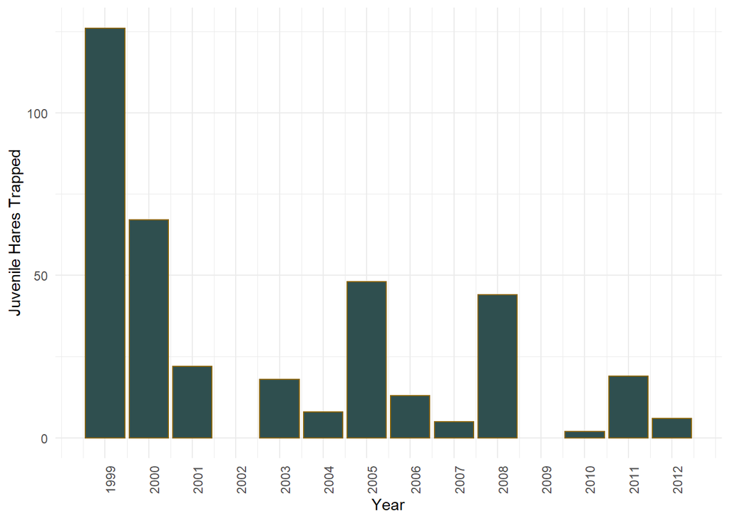

**Figure 1.** Annual juvenile hare trap counts. Annual counts of trapped juvenile hares from the Bonanza Creek Experimental Forest LTER site (1999-2012). Data: Kielland et al. 2017.

### 3.1.1 Summary

The minimum count of juvenile hares trapped for a given year was 0 (during 2002 and 2009) but the minimum non-zero number was 2 juvenile hares trapped in the year 2010. The maximum was 126 hares trapped, during 1999. The median number of juvenile hares trapped annually was 18.5 hares and the mean was 31.5 hares. One notable trend in the data is that the number of juvenile hares trapped annually generally decreased per year. Moving forward, I would suggest that the number of traps set be standardized across years, and recorded as part of the dataset. This would mean effort between years is the same, so the number of juvenile hares trapped is not impacted by sampling effort. Then, the data would more accurately reflect true hare populations.

## 3.2 Juvenile Hare Weights

This section includes a boxplot of juvenile hare body weight which is separated by sex and site. Also included is a table separated by sex and site which includes summary statistics (mean, median, standard deviation, sample size) about juvenile hare body weights.

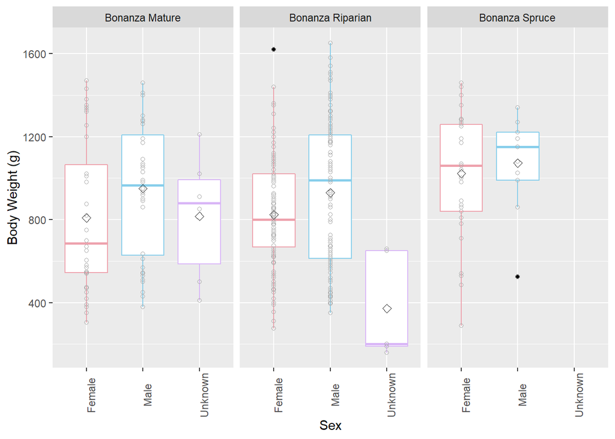

**Figure 2.** Distribution of body weights (g) for juvenile hares from Bonanza Creek Experimental Forest LTER site (1999-2012). Hares are grouped by sex and site. Individual data points are shown with hollow points and outliers are denoted by black points. The center lines in the boxes are the medians and the black hollow diamonds are means. The whiskers show minimums and maximums (not including outliers). Box endpoints are the 25th and 75th percentiles. Data: Kielland et al. 2017.

| Sex | Site | Mean (g) | Median (g) | Standard Deviation (g) | Sample Size |
| --- | --- | --- | --- | --- | --- |
| Female | Bonanza Mature | 808.19 | 685 | 361.12 | 36 |
| Female | Bonanza Riparian | 824.15 | 800 | 255.04 | 129 |
| Female | Bonanza Spruce | 1022.06 | 1060 | 292.96 | 35 |
| Male | Bonanza Mature | 950.12 | 965 | 314.69 | 40 |
| Male | Bonanza Riparian | 929.27 | 990 | 349.17 | 110 |
| Male | Bonanza Spruce | 1073.08 | 1150 | 222.64 | 13 |
| Unknown | Bonanza Mature | 816.67 | 880 | 307.09 | 7 |
| Unknown | Bonanza Riparian | 372.00 | 200 | 258.79 | 7 |
| Unknown | Bonanza Spruce | NA | NA | NA | 1 |

### 3.2.1 Summary

Mean and median body weights of juvenile hares are higher for males than females at all three sites. Juvenile hares with unknown sex only had recorded body weights at Bonanza Mature and Bonanza Riparian. For Bonanza Riparian, juvenile hares with unknown sex had much smaller mean and median weights compared to males and females at this site. Bonanza Spruce males and females had higher means and medians compared to all other sexes of juvenile hares (male, female, and unknown) at the other two sites.

## 3.3 Juvenile Weight Comparison By Sex

This section includes a table to compare juvenile body weight by sex. Summary statistics include mean, standard deivation and sample size. A Cohen’s d test and t-test were also run to determine effect size of sex on body weight and if the difference between body weights of males and females was significant.

**Table 2.** Weights of juvenile hares from Bonanza Creek Experimental Forest LTER site (1999-2012) grouped by sex. Summary statistics include mean (g), standard deviation (g), and sample size. Data: Kielland et al. 2017.

| Sex | Mean (g) | Standard Deviation (g) | Sample Size |
| --- | --- | --- | --- |
| Female | 855.39 | 292.25 | 200 |
| Male | 945.86 | 333.22 | 163 |

### 3.3.1 Summary

The mean weight of juvenile male hares (945.86 $\pm$ 333.22 g, n = 163) was larger than the mean weight of juvenile female hares (855.39 $\pm$ 292.25 g, n = 200). The mean weight of juvenile female hares is 9.56% smaller than the mean weight of juvenile male hares. The actual difference in mean weights is 90.47 g. Based on a Cohen’s d test, the effect of sex on body weight is not very large (d = 0.29) so the means are relatively close together. However, a t-test (Unpaired Welch Two Sample t-test: p-value = 0.007, t(325.02) = 2.71) shows that the effect is significant. This t-test reported a 0.71% chance of finding means at least 90.47 g different, if they are drawn from populations with the same mean. Diagnostic plots (histograms, Q-Q plots, not included here) showed observations and residuals were normally distributed.

## 3.4 Relationship Between Juvenile Weight & Hind Foot Length

This section includes a simple linear model to determine if hind foot length can predict body weight. This is visualized in a scatter plot of hind foot length versus body weight. Diagnostic models were created to check if the assumptions of the linear model are met (not included here). A test of correlation was also run to find Pearson’s r.

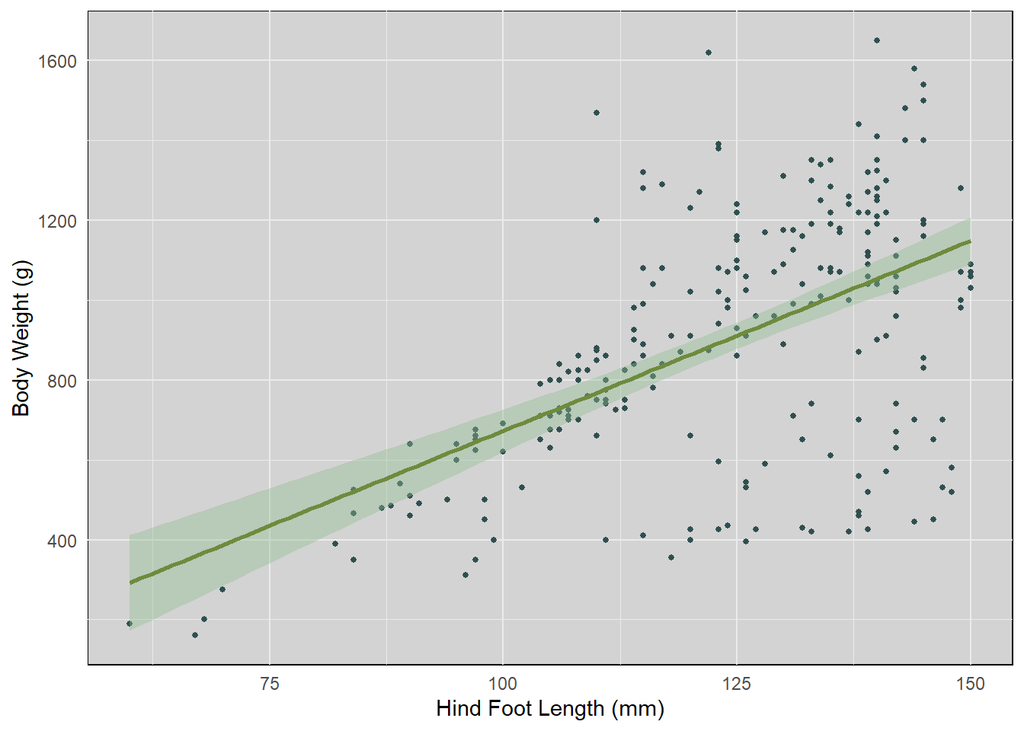

**Figure 3.** Relationship of hind foot length (mm) and body weight (g) of juvenile hares from Bonanza Creek Experimental Forest LTER site (1999-2012). Points indicate individual observations and the transparent green area of the line is the standard error. Linear model summary: $\beta_1$ = 9.52 g/mm, p < 0.001, R$^2$ = 0.3, Pearson’s r = 0.55. Data: Kielland et al. 2017.

### 3.4.1 Summary

If all other factors are held equal, then for every 1 mm increase in hind foot length, there is on average a 9.52 g increase in body weight for juvenile snowshoe hares. There is a moderate positive correlation between hind foot length and body weight (Pearson’s r = 0.55) but it is statistically significant (p value < 0.001). 30% of the variance in body weight can be explained by hind foot length (R$^2$ = 0.3).

However, I am concerned about the homoscedasticity of the data. In the residuals vs. fitted plot (not included in this report), the residuals’ variance increases with weight so the data is heteroscedastic. Additionally, the Q-Q plots (not included in this report) show that the residuals are somewhat non-normally distributed, especially at low weights. On top of not fitting assumptions for a linear model, the model also does not include sex or site, which seem to be important variables in predicting body weight (Table 2, Figure 2).

# 4 Overall Summary

- The number of juvenile hares trapped annually at Bonanza Creek Experimental Forest LTER generally decreased from 1999 to 2012.
- On average, juvenile male hares weigh more than juvenile females at all sites. Of the 3 sites (Bonanza Mature, Bonanza Riparian, Bonanza Spruce). Bonanza spruce had the largest hares for both sexes.
- The actual difference in mean weights of juvenile hares of both sexes was 90.47 g. The t-test and Cohen’s d test showed a significant but small effect of sex on body weight (Welch Two Sample t-test p-value = 0.007, Cohen’s d = 0.29).
- There was a moderate but statistically significant positive correlation between hind foot length and body weight (p value < 0.001, Pearson’s r = 0.55). Body weight is not well predicted by only hind foot length (R$^2$ = 0.3). Diagnostic plots (not included in the report) showed that assumptions of a simple linear model were not met.

Next Steps

- Change data-taking methods to be more consistent with number of traps set per year
- Include effort level in calculations of annual hares trapped from 1999 to 2012
- Try a multiple linear regression to determine the effect of sex, site and hind foot length on body weight

# 5 Citations

Kielland, K., F.S. Chapin, R.W. Ruess, and Bonanza Creek LTER. 2017. Snowshoe hare physical data in Bonanza Creek Experimental Forest: 1999-Present ver 22. Environmental Data Initiative. https://doi.org/10.6073/pasta/03dce4856d79b91557d8e6ce2cbcdc14